# Practical Machine Learning

Zeeshan Abbasi

Sunday, May 24, 2015

# Executive Summary

The data from the various subjects was collected while the they were performing execises so that the quality of their training could be evaluated and future sessions could be catagorised based on a trained model. Out task is to train a model from the given data “pml-training.csv” and then predict the classes based on the test data “pml-testing.csv”.

# Methodology

# The Program (First Pass)

When I started training the three models (SVM, GBM, RF) using the caret package it took several hours to complete the computation and the results were decisive. The Random Forest model outperformed the other two and I got my results as expected. Then I opted to optimize my program so that it takes less time and the code is cleaner in the second pass.

*I could not add the code for the first run due to not being able to run it in the RStudio as I did not understand the difference between RStudio and RGui and that computation is done in RGui where I could not run MarkDown. A second run of that code will take hours.*

**Plots comparing the models from the caret package.**

**Dot Plot**

[figure not shown]

**Box Plot**

[figure not shown]

**Confusion Matrix**

**GBM**

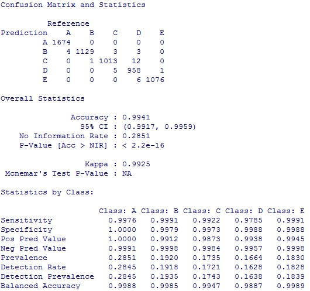

**Random Forest**

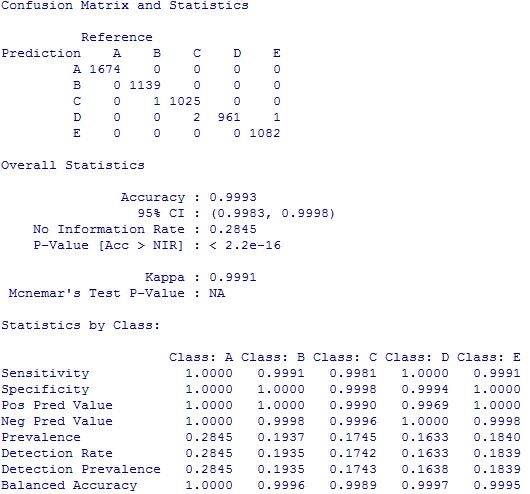

**SVM**

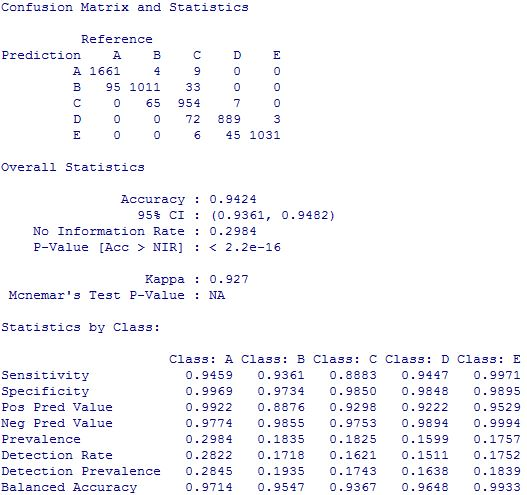